# 実行可能形式ファイルの作成

> オブジェクト指向プログラミングおよび演習1 第5回

> Javaプログラムを配布できる形式にする方法(IntelliJ IDEA使用)

*次回の講義で使用するSimpleRPGプログラムを例にしている箇所があります。適宜読み替えてください。*

## Javaのコンパイル済みプログラムを実行可能形式として作成する

Javaプログラムを配布する場合、`jar`と呼ばれる実行可能形式としてパッケージングする必要があります。

IDEとして使用しているIntelliJ IDEAでは、以下の手順でプロジェクト単位のパッケージング設定が行えます。

### 成果物の設定

各設定項目の()内は日本語化していない場合のメニュー名です。

1. ツールバーの「ファイル(File)」 → 「プロジェクト構造(Project Structure)」を選択
2. 「プロジェクト構造(Project Structure)」ウィンドウが開きますので、次の図を参考に、「成果物(Artifacts)」を選択、上部「＋」ボタンをクリック、「JAR」→「依存関係を持つモジュールから (From modules with dependencies...)」を選択

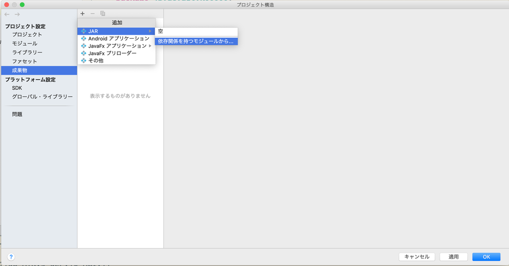

3. 次の図を参考に、「メイン・クラス(Main Class)」の入力欄右にあるボタンをクリック

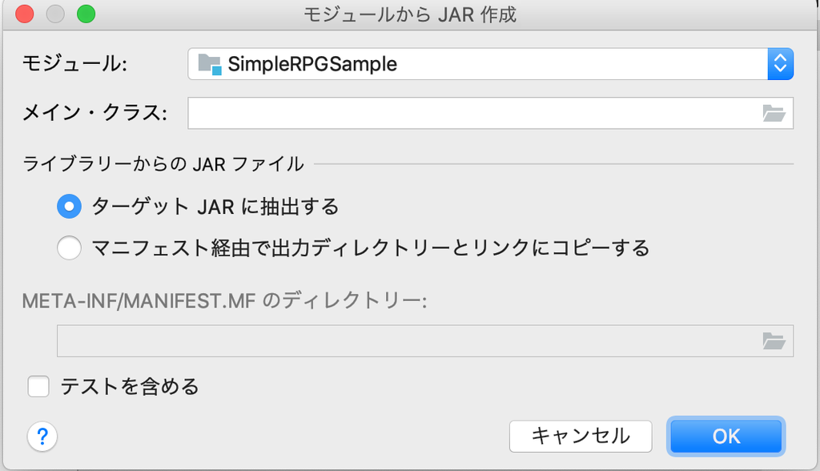

4. mainメソッドを持つクラスが一覧表示されるので、実行させたいメインクラスを選択して「OK」を選択
   - 今回は、SimpleRPG.java内のmainメソッドを選択してください。

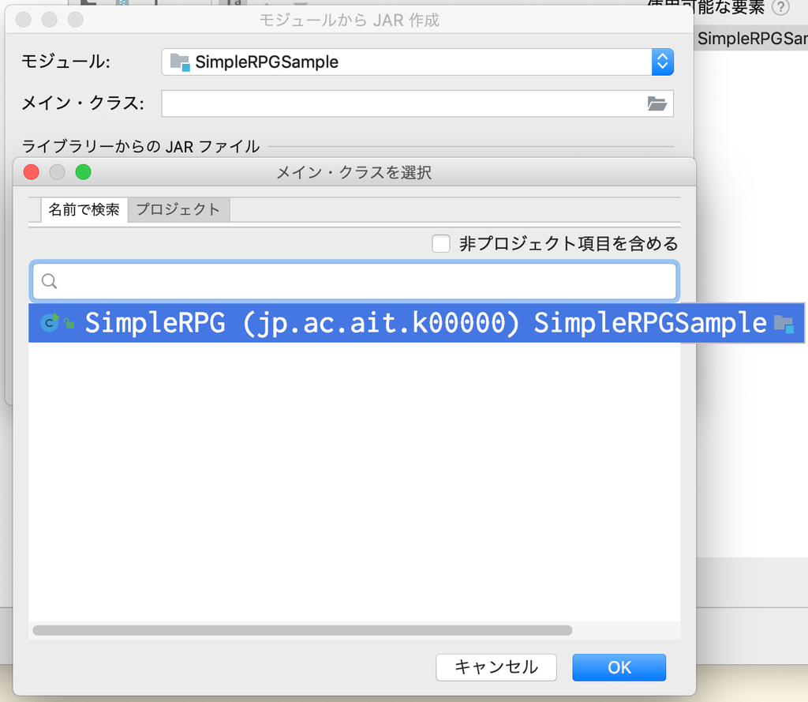

5. 3.のときの画面に戻って、先程選択したメインクラスが設定されてるかを確認して「OK」を選択

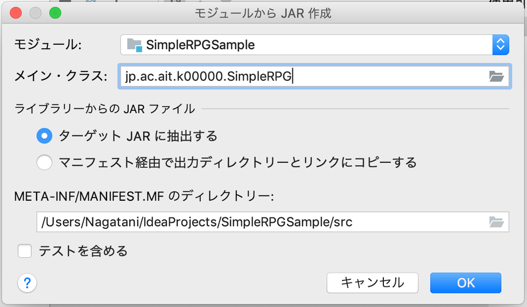

6. 「プロジェクト構造(Project Structure)」のウィンドウも「OK」を選択して閉じます

設定は以上です。

### 成果物(jar)ファイルの生成

設定した成果物を生成するには、以下の手順に従います。  
*※ 自動では実行されないので、プログラムを提出する直前にこの手順を行ってください。*

1. ツールバーの「ビルド(Build)」→「成果物のビルド(Build Artifacts...)」を選択
2. 次の図のような小さなウィンドウが画面中央に出るので、そのメニューから「Build」を選択

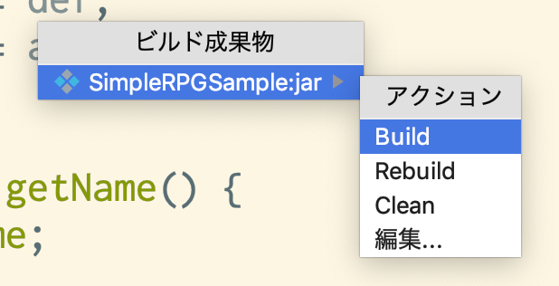

3. コンパイルエラーもなく、正常にビルドが終わると、次の図のようにプロジェクトフォルダの中の「out」ディレクトリの「artifacts」ディレクトリ内にjarファイルが生成されています。

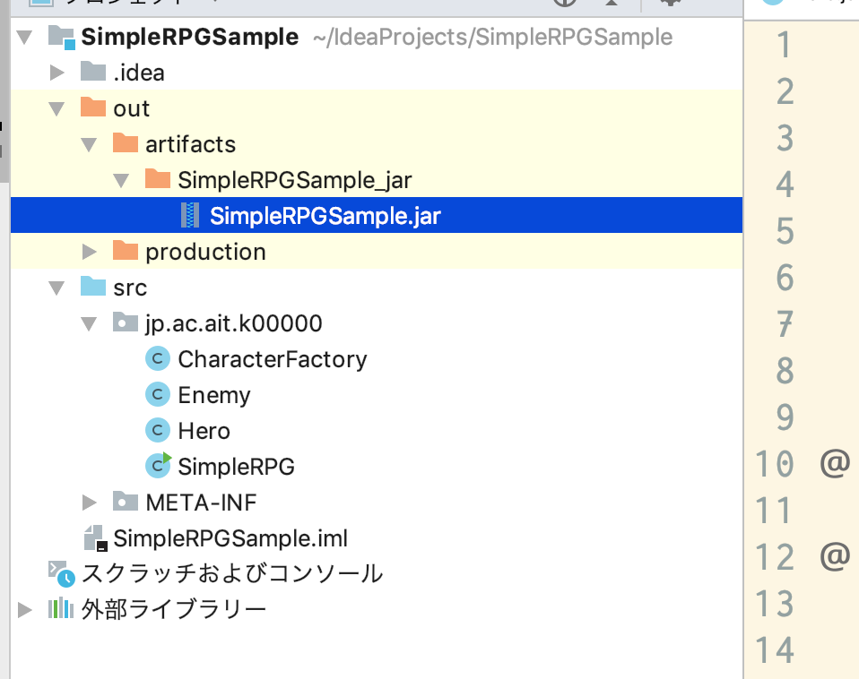

### 成果物を実行して確かめる

プロジェクトディレクトリが、`~/IdeaProjects/SimpleRPG`にあるものとして、ターミナルにて以下のコマンドを実行することで成果物の動作確認が行えます。

```bash
$ cd ~/IdeaProjects/SimpleRPG
$ cd out/artifacts/SimpleRPG_jar
$ java -jar SimpleRPG.jar
```

プロジェクトディレクトリは、プロジェクトを新規作成した際に指定したディレクトリです。

動作確認を行ってからファイル提出を行うようにしてください。

# 補足資料(JARファイルの生成に関して)

## クラスファイルのパッケージング

Javaのアプリケーションやライブラリをjarファイルにパッケージングするには、`jar`コマンドを使用します。

コマンドのテンプレートは以下のようになっています。

```bash
$ jar オプション jarファイル名 含めるクラスファイル…
```

カレントディレクトリ以下のJavaクラスをすべてsample.jarという名前でパッケージングするには、以下のようにコマンドオプションを指定します。

サンプルソースはmoodleにアップロードしています。

```bash
$ javac jp/ac/ait/oop2/jarsample/Sample.java
$ jar -cf sample.jar .
```

これでjarファイルの作成は可能です。ライブラリとして他のクラスから参照するだけであればこれで問題はありませんが、このままでは実行可能なjarファイルではありません。

実行可能なjarファイルを作成するには、manifest.mfと呼ばれる設定ファイルが必要です。  
サンプルソースには、それが含まれています。

中身に設定する内容は、以下の様になっています。

```
Manifest-Version: 1.0
Main-Class: jp/ac/ait/oop2/jarsample/Sample
```

Main-Classオプションで、jarファイル自体のメインクラスを指定します。

これを、jarコマンドで追加指定してあげることで実行可能形式に変更できます。

```
$ jar -cfm sample.jar manifest.mf .
$ java -jar sample.jar
```

#### jarコマンドの主なオプション

| オプション | 概要 |
| --- | --- |
| -c | 新規にJARファイルを作成 |
| -u | 既存のJARファイルを更新 |
| -x | JARファイルの内容を抽出 |
| -t | JARファイルの内容をリスト表示 |
| -f | 対象のJARファイルを指定 |
| -m | MANIFESTファイルを使用してjarファイルの詳細な設定を指定 含めるクラスファイルの中に、MANIFEST.MFというファイルが必要です。 **ダブルクリックで実行可能なjarファイルを作るには、このオプションの指定が必須です！** |